# Métodos Computacionais para Análise de Risco

25 de junho de 2018

## Análise Descritiva

## Descrição dos dados

- O banco de dados escolhido é o *Swedish Motor Insurance dataset*.
- Os dados são referentes aos seguros de automóveis sueco, e foram coletados em 1977 pelo *Swedish Committee on the Analysis of Risk Premium* (Comitê Sueco para a Análise do Prêmio de Risco).
- O banco de dados possui 7 variáveis e 2.182 observações.

## Descrição dos dados

- As variáveis do banco de dados são:

Kilometres: quilômetros percorridos por ano. Agrupada em 5 categorias: 1) <1.000; 2) 1.000-15.000; 3) 15.000-20.000; 4) 20.000-25.000 e 5) >25.000

Zone: zona geográfica. Agrupada em 7 categorias: 1) Stockholm, Göteborg, Malmö e arredores; 2) Outras cidades grandes e arredores; 3) Pequenas cidades e arredores no sul da Suécia; 4) Áreas rurais no sul da Suécia; 5) Pequenas cidades e arredores no norte da Suécia; 6) Áreas rurais no norte da Suécia e 7) Gotland.

Bonus: experiência de aviso do motorista. Agrupada em 7 categorias, igual ao número de anos, mais um, desde o último aviso.

## Continuação

Make: tipo do veículo. Agrupado em 9 categorias: 1-8) representam oito modelos diferentes de carro comum e 9) todos os outros modelos são combinados nessa classe.

Insured: número de anos segurados.

Claims: número de reivindicações.

Payment: soma dos pagamentos (em milhares de coroas suecas).

## Descrição dos dados

```
##    Kilometres         Zone          Bonus            Make
##  Min.   :1.000   Min.   :1.00   Min.   :1.000   Min.   :1.000
##  1st Qu.:2.000   1st Qu.:2.00   1st Qu.:2.000   1st Qu.:3.000
##  Median :3.000   Median :4.00   Median :4.000   Median :5.000
##  Mean   :2.986   Mean   :3.97   Mean   :4.015   Mean   :4.992
##  3rd Qu.:4.000   3rd Qu.:6.00   3rd Qu.:6.000   3rd Qu.:7.000
##  Max.   :5.000   Max.   :7.00   Max.   :7.000   Max.   :9.000
##     Insured              Claims           Payment
##  Min.   :     0.01   Min.   :   0.00   Min.   :       0
##  1st Qu.:    21.61   1st Qu.:   1.00   1st Qu.:    2989
##  Median :    81.53   Median :   5.00   Median :   27404
##  Mean   :  1092.20   Mean   :  51.87   Mean   :  257008
##  3rd Qu.:   389.78   3rd Qu.:  21.00   3rd Qu.:  111954
##  Max.   :127687.27   Max.   :3338.00   Max.   :18245026
```

## Análise das distribuições das variáveis contínuas

- Distribuição da variável Soma dos Pagamentos:

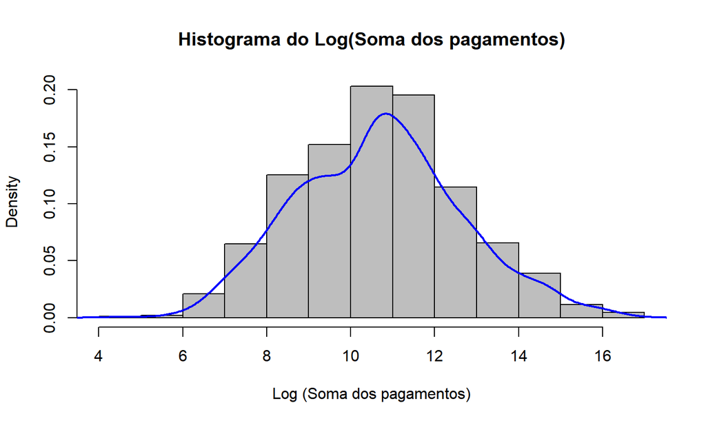

## Análise das distribuições das variáveis contínuas

- Distribuição da variável Número de Reivindicações:

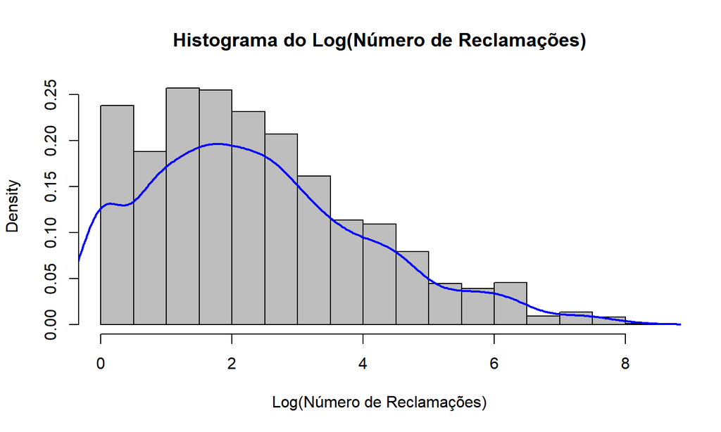

## Análise das distribuições das variáveis contínuas

- Distribuição da variável Log(Número de anos segurados):

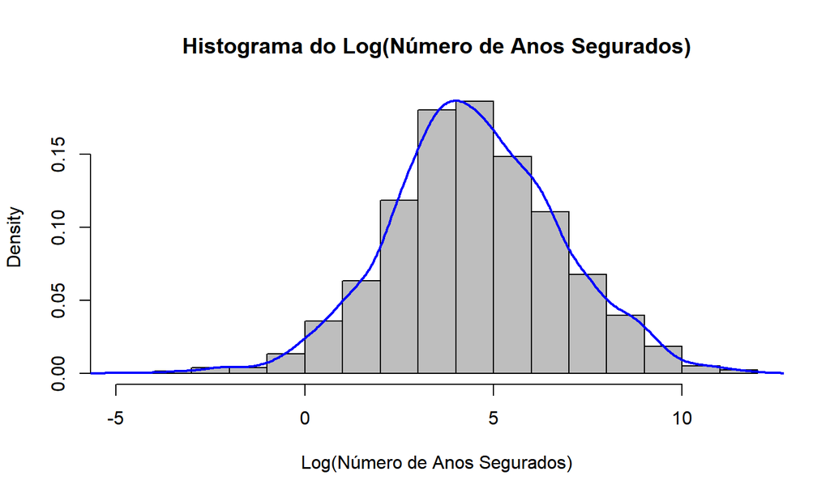

## Relações entre as variáveis

- Distribuição da Soma de Pagamentos segundo o Número de Reivindicações e o Número de Anos Segurados.

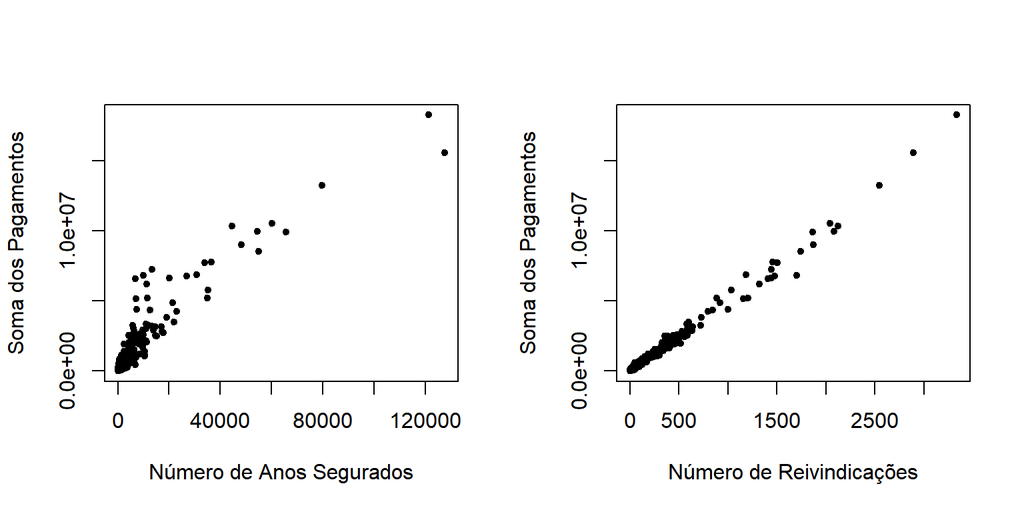

  Os valores dos pagamentos aumentam com o tempo de exposição e o com o número reivindicações de forma linear.

## Frequência de Reivindicações

Para compreender os efeitos das variáveis explicativas sobre a frequência de reivindicações, apresentamos boxplots com o número médio de reivindicações por segurado versus cada variável categórica.

## Frequência de Reivindicações por Distância Percorrida e Zona Geográfica

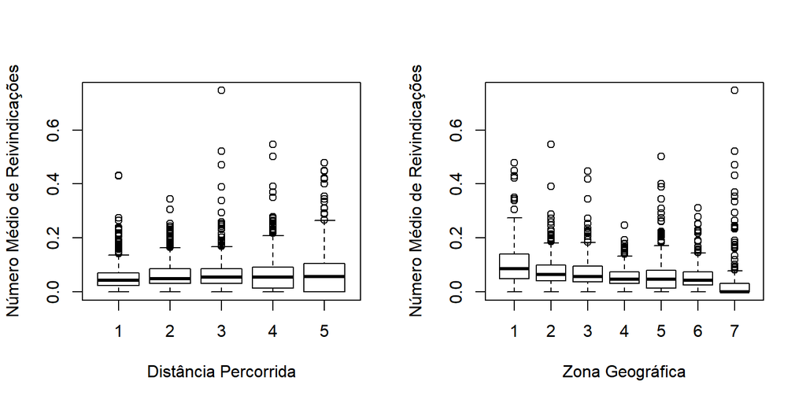

Verifica-se frequências mais baixas associadas a distâncias menores e a zonas não urbanas.

## Frequência de Reivindicações por Bônus e Modelo do Veículo

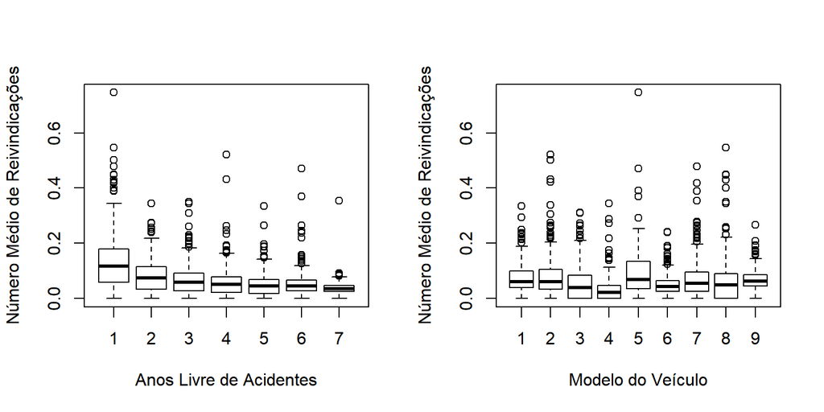

Frequências mais baixas de reivindicações estão associadas com um maior nível de Bônus (anos livres de acidentes) e quanto ao tipo de automóvel verifica-se que impacta bastante no número de reivindicações.

## Severidade das Reivindicações

Para a severidade dos sinistros, apresentamos boxplots com o pagamento médio do sinistro versus cada variável categórica.

## Severidade das Reivindicações por Distância Percorrida e Zona Geográfica

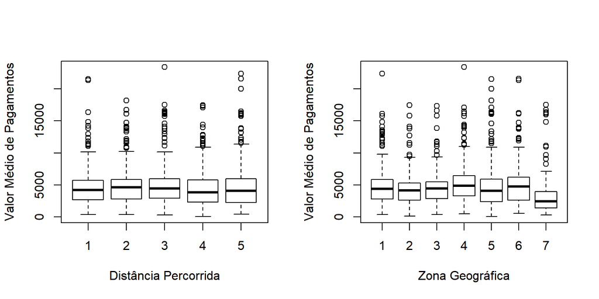

Observa-se que o Valor Médio de Pagamentos por Reivindicação praticamente não muda para a Distância Percorridapor ano. A análise por Zona Geográfica mostra que a Zona 7 possui severidade média muito menor que as demais.

## Severidade das Reivindicações por Bônus e Modelo do Veículo

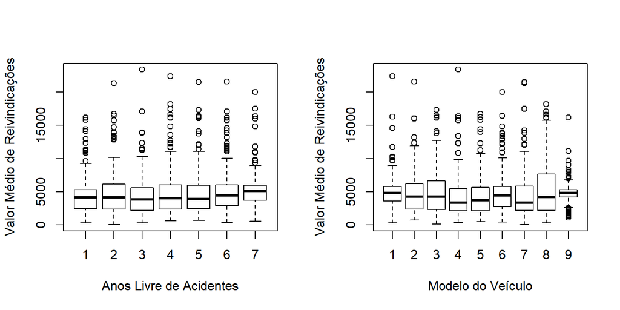

O Modelo do veículo resulta em grande variação no Valor Médio dos Pagamentos.

## Inferência e Ajuste

## Ajuste para a Frequência - Poisson

Usamos um modelo de regressão de Poisson com função de ligação logarítimica para modelar a frequência de reivindicações. O modelo foi ajustado usando máxima verossimilhança. As categorias de referência correspondem à primeira de cada variável.

```
##
## Call:
## glm(formula = swautoins$Claims ~ factor(swautoins$Kilometres) +
##     factor(swautoins$Zone) + factor(swautoins$Bonus) + factor(swautoins$Make),
##     family = poisson(link = log), offset = log(swautoins$Insured))
##
## Deviance Residuals:
##     Min       1Q   Median       3Q      Max
## -6.9854  -0.8626  -0.1718   0.5997   6.4005
##
## Coefficients:
##                                Estimate Std. Error  z value Pr(>|z|)
## (Intercept)                   -1.812840   0.013757 -131.775  < 2e-16 ***
## factor(swautoins$Kilometres)2  0.212586   0.007524   28.255  < 2e-16 ***
## factor(swautoins$Kilometres)3  0.320226   0.008661   36.974  < 2e-16 ***
## factor(swautoins$Kilometres)4  0.404657   0.012054   33.571  < 2e-16 ***
## factor(swautoins$Kilometres)5  0.575954   0.012830   44.892  < 2e-16 ***
## factor(swautoins$Zone)2       -0.238168   0.009496  -25.082  < 2e-16 ***
## factor(swautoins$Zone)3       -0.386395   0.009670  -39.959  < 2e-16 ***
## factor(swautoins$Zone)4       -0.581902   0.008654  -67.243  < 2e-16 ***
## factor(swautoins$Zone)5       -0.326128   0.014530  -22.446  < 2e-16 ***
## factor(swautoins$Zone)6       -0.526234   0.011877  -44.309  < 2e-16 ***
## factor(swautoins$Zone)7       -0.730999   0.040698  -17.962  < 2e-16 ***
## factor(swautoins$Bonus)2      -0.478993   0.012094  -39.607  < 2e-16 ***
## factor(swautoins$Bonus)3      -0.693172   0.013508  -51.316  < 2e-16 ***
## factor(swautoins$Bonus)4      -0.827397   0.014584  -56.735  < 2e-16 ***
## factor(swautoins$Bonus)5      -0.925632   0.013968  -66.269  < 2e-16 ***
## factor(swautoins$Bonus)6      -0.993457   0.011629  -85.429  < 2e-16 ***
## factor(swautoins$Bonus)7      -1.327406   0.008685 -152.845  < 2e-16 ***
## factor(swautoins$Make)2        0.076245   0.021239    3.590 0.000331 ***
## factor(swautoins$Make)3       -0.247413   0.025094   -9.859  < 2e-16 ***
## factor(swautoins$Make)4       -0.653524   0.024185  -27.022  < 2e-16 ***
## factor(swautoins$Make)5        0.154924   0.020235    7.656 1.91e-14 ***
## factor(swautoins$Make)6       -0.335581   0.017375  -19.314  < 2e-16 ***
## factor(swautoins$Make)7       -0.055940   0.023343   -2.396 0.016554 *
## factor(swautoins$Make)8       -0.043933   0.031604   -1.390 0.164493
## factor(swautoins$Make)9       -0.068054   0.009956   -6.836 8.17e-12 ***
## ---
## Signif. codes:  0 '***' 0.001 '**' 0.01 '*' 0.05 '.' 0.1 ' ' 1
##
## (Dispersion parameter for poisson family taken to be 1)
##
##     Null deviance: 34070.6  on 2181  degrees of freedom
## Residual deviance:  2966.1  on 2157  degrees of freedom
## AIC: 10654
##
## Number of Fisher Scoring iterations: 4
```

## Continuação

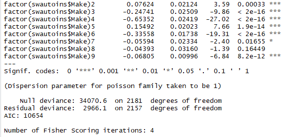

## Ajuste para a Frequência - Poisson

Ex.: Um motorista mora na Zona Geográfica 1, dirige entre 1 e 15 mil km por ano (kilometres = 2), teve 1 acidente no último ano (Bônus=1) e dirige o tipo de veículo 6. A partir dos coeficientes: -1.813 + 0.213 - 0.336 = -1.936 Para uma apólice dessa combinação, estimamos um número de reivindicações com exp(-1.936) = 0,144. A probabilidade de não haver reivindicações no ano é 0.866.

## Ajuste para a Severidade - Gama

Para a Severidade das Reivindicações ajustamos um modelo de regressão Gama, usando a função de link logarítimica, e a máxima verossimilhança. Optamos pelo ajuste de um modelo apenas com as variáveis explicativas Zona Geográfica e Modelo do Veículo.

```
##
## Call:
## glm(formula = swautoins3$Payment ~ factor(swautoins3$Zone) +
##     factor(swautoins3$Make), family = Gamma(link = log), weights = Weight,
##     offset = log(swautoins3$Claims))
##
## Deviance Residuals:
##      Min        1Q    Median        3Q       Max
## -2.56968  -0.39928  -0.06305   0.07179   2.81822
##
## Coefficients:
##                          Estimate Std. Error t value Pr(>|t|)
## (Intercept)               8.38767    0.10933  76.722  < 2e-16 ***
## factor(swautoins3$Zone)2 -0.06099    0.09515  -0.641  0.52156
## factor(swautoins3$Zone)3  0.15290    0.09573   1.597  0.11041
## factor(swautoins3$Zone)4  0.09223    0.09781   0.943  0.34583
## factor(swautoins3$Zone)5  0.19729    0.09313   2.119  0.03427 *
## factor(swautoins3$Zone)6  0.24205    0.09377   2.581  0.00992 **
## factor(swautoins3$Zone)7  0.10566    0.10804   0.978  0.32825
## factor(swautoins3$Make)2 -0.04963    0.11306  -0.439  0.66071
## factor(swautoins3$Make)3  0.25309    0.11404   2.219  0.02660 *
## factor(swautoins3$Make)4  0.04948    0.11634   0.425  0.67067
## factor(swautoins3$Make)5  0.09725    0.11419   0.852  0.39454
## factor(swautoins3$Make)6  0.10781    0.11658   0.925  0.35517
## factor(swautoins3$Make)7 -0.02040    0.11313  -0.180  0.85692
## factor(swautoins3$Make)8  0.32623    0.11247   2.900  0.00377 **
## factor(swautoins3$Make)9 -0.06377    0.15061  -0.423  0.67205
## ---
## Signif. codes:  0 '***' 0.001 '**' 0.01 '*' 0.05 '.' 0.1 ' ' 1
##
## (Dispersion parameter for Gamma family taken to be 0.4830309)
##
##     Null deviance: 617.32  on 1796  degrees of freedom
## Residual deviance: 596.79  on 1782  degrees of freedom
## AIC: 16082
##
## Number of Fisher Scoring iterations: 7
```

## Continuação

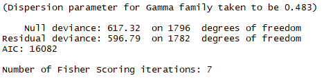

## Ajuste para a Severidade - Gama

Pelo summary do modelo veificamos que as categorias de referência são a Zona 1 e o Modelo do Veículo 1. Ex.: Um motorista que mora na Zona 1 e possui veículo do tipo 6 : 8.388 + 0.108 = 8.496 A expectativa de valor do pagamento é de exp(8.496) = 4.895 (em milhares de coroas suecas)

## Bibliografia

## Referências Bibliográficas

Frees (2010), Regression modelling with actuarial and financial applications, Cambridge University Press.